# Einführung in AutoCAD für Archäologen

Christoph Rinne

25. April 2023

# Plotten - Grundlagen

In der vorangehenden Übung haben wir die Arbeit am sogenannte **Heiligtum von Son Oms** (Son Vidal Nou, Palma de Mallorca) fortgesetzt (Rosselló Bordoy, 1984). Für die Wände sind die Bilder getrennt in einem jeweils eigenen Benutzerkoordinatensystem eingefügt, angepasst und die Steine digitalisiert worden. In einem folgenden Schritt sind diese Dateien als externe Referenzen verknüpft und nachfolgend gebunden worden (binden-binden, binden-einfügen). Mit dieser Einführung in das Plotten sind wir durch die Grundlagen in der Arbeit mit AutoCAD durch.

Nachfolgend wird ein Layout mit mehreren Ansichtsfenste bzw. diversen Sichten auf unser Modell entworfen. Zur Wiederholung erstelle ich die beim Binden der Referenzen verlorenen BKS für die Wände erneut her, da diese für die Ansichten im Plot hilfreich sind. Ich blende dafür alle Stein-Layer aus, was mit dem Layerfilter “*Steine*” schnell erledigt ist und drehe mit dem View-Cube die Ansicht des Modells so, dass ich die Eckpunkte des jeweiligen Profilbildes gut sehe. Danach nutzen ich dann “Extras -> Neues BKS -> 3-Punkte”, fange die Bildecken und benenne die aktuelle Ansicht dann um (A-Wand etc.).

## Plan erstellen

Für jedes Modell können Sie mit [+] weitere, zahlreiche Layout erstellen, dabei wird automatisch ein Ansichtsfenster generiert und auf dem aktiven Layer abgelegt. Die wichtigsten Dinge für die Arbeit im Papierbereich:

- Legen Sie für die Objekte im Papierbereich eigene Layer an, Sie vermeiden nervenraubende Fehler durch ausgeblendete und gesperrte Layer.
- Layout-Objekte liegen nur im Papierbereich (Maßstab, Beschriftungen, Rahmen etc.).
- Der Papierbereich kennt nur Millimeter oder Zoll und das Verhältnis zwischen der Zeicheneinheit im Modell und der Papiereinheit (Plottmaßstab). Da Archäologie, entgegen der Standardvorgabe, fast ausnahmslos in Meter misst, beträgt der Plottmaßstab 1 mm = 0.001 Einheit.
- AutoCAD hat einen sehr guten eigenen PDF-Drucker (DWG To PDF), er reproduziert die Layer der Zeichnung als Ebenen in der PDF-Datei, so dass Aus- und Einblenden auch dort möglich ist.
- Mit `mbereich` und `pbereich`, “MODELL/PAPIER” in der Fußzeile oder Doppelklick innerhalb und außerhalb des Ansichtsfensters “springen Sie durch das Fenster in das Modell”.

### Layout - Seite einrichten

Falls noch nicht geschehen, erstellen Sie einen neuen Layer “Papier-Layout”, Farbe: weiß (schwarz im Papier) und schalten Sie diesen aktiv. Es existiert immer mindestens ein Layout (Layout1), aktivieren Sie dieses. Rufen Sie den **Seiteneinrichtungs-Manager** auf: `_pagesetup`, `seinteneinr`, “Datei -> Seiteneinrichtungs-Manager” oder Kontextmenü des Layoutregisters. Wählen Sie das Layout (Layout1) und [ändern]. Drucker/Plotter: DGW To PDF.pc3, Papier: DinA4 (210 x 297) / ISO full bleed A4…, Plottmaßstab: 1 mm = 0.001 Einheit (s.o.).

Der *Plotbereich* kann gewählt werden, üblich ist aber das jeweils gestaltete Layout. *Plotstiltabelle (Stiftzuordnung)*: “Keine”, Diese Einstellung hat im Laufe der Zeit einen Funktionswandel erlebt. Früher wurde über die Farbe die Strichstärke bei Stiftplottern gesteuert, heute bietet es eher die Option “Grau” oder “Monochrom” für den Plan zu wählen. Unser Plan wird ein Querformat. Die weiteren Angaben sind selbsterklärend oder vorerst uninteressant und bleiben unverändert. Da ich fast ausnahmslos in PDF Plotte ist die [Vorschau] für mich weniger relevant. Beim direkten Plot von Großformaten auf einem Papierplotter sollten Sie hiermit aber das Ergebnis vorab kontrollieren. Bestätigen Sie die Änderungen mit [OK] und schließen Sie den Manager.

### Ansichtsfenster - Darstellung einfügen

Durch den veränderten Plottmaßstab (s.o.) ist Ihr bisheriges Ansichtsfenster 1000fach vergrößert `(zoom g[renzen])`. Da wir es neu gestalten löschen sie es einfach. Zeichnen Sie als “Satzspiegel” ein Rechteck mit den Ecken “.02,.02” und “.277,.19” (Blattkoordinaten in Meter). Die weitere Aufteilung sehen sie in der nächsten Abbildung.

Zeichnen Sie danach mit “Ansicht -> Ansichtsfenster -> 1 Ansichtsfenster” ein neues Ansichtsfenster von der rechten oberen Ecke des Satzspiegels horizontal etwa über 1/3 der Breite und vertikal etwa über 3/4 des Satzspiegels. Rufen Sie die Eigenschaften auf: Höhe: 0.11, Breite 0.11, Benutzerspezifischer Faktor 0.005. Das entspricht der Skalierung 1:200 (200 x 0.005 = 1) und wenn nicht, stellen Sie bei Ansichtsfenstermaßstab 1:100 ein (0.01) und halbieren Sie diesen Wert. Schieben Sie das Ansichtsfenster in die rechte obere Ecke (OFang). Wechseln Sie mit einem Doppelklick in dieses Ansichtsfenster, stellen spätestens jetzt auf WKS (Planansicht) um und Schieben Sie den Plan im Fenster in die Mitte. Wechseln Sie wieder in den Papierbereich (Doppelklick außerhalb oder `pbereich`).

Zeichnen Sie nun “2 Ansichtfenster”, Anordnung horizontal (h), von links oben des Satzspiegels zur linken unteren Ecke des 1. Ansichtsfensters. Ändern Sie für beide Ansichtsfenster die Eigenschaften: Höhe 0.0425, Maßstab/Faktor: 0.01 und schieben Sie diese exakt untereinander ab der linken oberen Ecke des Satzspiegels. Kopieren Sie diese beiden Ansichtsfenster (<strg>+<c>) und fügen Sie die neuen unterhalb der vorangehenden an (<strg>+<v>). Im Ergebnis sollten Sie eine Abfolge von vier Ansichtsfenstern in der linken Hälfte des Satzspiegels haben.

### Ansichtsfenster - Inhalt und Darstellung

Die einzelnen Ansichtsfenster (AF) zeigen jeweils alle Daten in der Aufsicht des WKS, dies wird nachfolgend verändert. Wir starten mit der großen Ansicht auf den Grundriss. Markieren Sie das AF und wechseln Sie in den Modellbereich (alternativ Doppelklick in das AF). Öffnen Sie den Layermanager, markieren Sie alle Layer bis auf Papier* und Plan* und schalten Sie diese mit “AF frieren” in der Eigenschaftenliste für diese Ansicht aus. Wiederholen Sie diesen Vorgang für die vier AF am linken Rand, wählen Sie jeweils A-, B-, C, und D-Wand sowie den Papier-Layer als nicht gefroren.

[output not shown]

Nachfolgend soll jede Wand in die frontale Ansicht (BKS: Oben) gebracht werden. Zoomen Sie auf die rechte Hälfte des jeweiligen AF, “springen” Sie in das Modell, schalten Sie in das jeweilige BKS und nutzen Sie den *view-Cube* für die Rotation in die korrekte Ansicht (Oben). Positionieren Sie die Zeichnung angemessen in dem AF, bedenken Sie dabei die spätere Position eines Buchstabens für die Beschriftung.

Ein *horror vacui* ist weit verbreitet. Um dieser Angst zu frönen, könnten wir in der linken Hälfte des verbleibenden freien Raumes noch eine 3-D-Ansicht einbauen, die Kenntnis hierzu haben Sie jetzt.

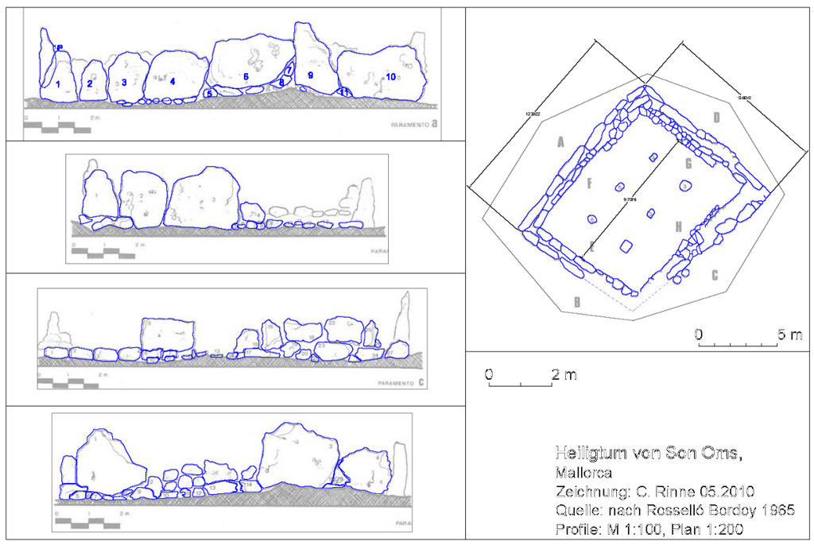

3D-Modell des Heiligtum von Son Oms. Plott mit 5 Ansichtsfenstern

### Beschriftung und weitere Elemente

Erstellen Sie in der rechten Hälfte des verbleibenden freien Raumes noch einen erläuternden Text. Was sollte dort stehen?

- Titelei: Plantitel, Maßnahme, Ort, Projektangaben, Planersteller/Verantwortlicher
- Technisches: Koordinatensystem, Maßstab, Maßstabsleiste, Nordpfeil
- Ablage, Version und Stand: Dateiname, Plottdatum, Speicherdatum

Diese Angaben sind wichtige Metadaten. Sie lassen sich interaktiv vom Nutzer oder teilweise auch von den Objekten und der Datei automatisch abfrage. Zusammen mit der Gestaltung einer Plottvorlage ist dies Teil einer anderen Übung.

### Text im Layout

Mit dem Befehl `mtext` fügen Sie einen Absatztext ein und ziehen dafür bitte eine Box in der rechten Hälfte des freien Raumes auf. Schreiben Sie erst nur “Heiligtum von Son Oms” und schließen Sie mit [OK] ab. Die Textgröße hängt natürlich von dem angegeben Wert bzw. dem zuletzt verwendeten Wert ab. Bei mir war das “0.2” und ist viel zu groß. Rufen Sie die Eigenschaften für den MText auf und ändern Sie die Texthöhe in “0.004”.

Was ist das für eine Größe? Nun es ist natürlich unsere Einheit, also Meter und entsprechend 4 mm Texthöhe. Umrechnung: 1 mm entspricht ca. 2.84 pt. Der Text ist also ca. 11.5 pt groß. Ergänzen Sie in vier Zeilen: “Mallorca / Zeichnung: <Name> <Datum> / Quelle: nach Rosselló Bordoy 1984 / Profile: M 1:100, Plan: 1:200”. Markieren Sie diesen Text und reduzieren Sie die Größe auf 0.0035. Verändern Sie die Größe der Textbox bis Sie fünf Zeilen haben und schieben Sie alles nach rechts unten.

### Maßstabsleiste ergänzen

Das wichtigste vorweg: nein, es gibt keinen “Knopf” für diese Aufgabe. Ich möchte dies nutzen, erneut auf die Maßstabsbeziehungen von Modell, Papier und Ansichtsfenster einzugehen. “Springen” Sie in die Plandarstellung hinein (AF, Maßstab 0.005). Zeichnen Sie dort bitte eine horizontale Linie von 1 m Länge (`@1<0`). Wechseln Sie wieder in den Papierbereich. 1 m im Modell = 1000 mm im Papier. Der Maßstabfaktor des AF ist 0.005 , also 1 Einheit des Modells = 0.005 Einheiten in der Darstellung. Ich muss nicht rechnen, sondern zeichne im Papier eine Linie mit der Länge 0.005 `@0.005<0`. Die Länge der beiden gezeichneten Linien sieht sehr ähnlich aus.

Ich vertraue der vorangehenden Überlegung, ergänze an den Enden der letzten Linie zwei kurze vertikale Linien `@0.001<90` und baue unter Ausschluss der linken Vertikalen eine Reihe mit 5 Spalten, 1 Zeile und dem ABstand von 0.005. Wiederholen Sie dies für die Profilansichten (Maßstabfaktor: 0.01). Vertikale Linie 0.001 und 2 Spalten bei der Reihe für eine 2 m lange Maßstabsleiste. Ergänzen Sie bitte eine Beschriftung für beide Leisten und positionieren Sie diese eigenständig. Ergänzen Sie zudem bitte noch eine Beschriftung für die einzelnen AF (A für Wand A etc).

Drucken Sie das Layout in ein PDF (DWG To PDF).

### PDF mit vielen Layern

Die Layer bzw. die Ebenen in einem PDF können ein- und ausgeblendet werden. Sie können damit in einem PDF z.B. viele Plana oder diverse Fundkategorien hinterlegen und der Nutzer hat die Wahl zur Darstellung der gewünschten Information. Die Vorgabe für die Ebenen (An/Aus) und auch die Sichtbarkeit des Ebenen-Fensters können in der Software **Adobe Acrobat Professional** eingestellt werden. Unter den Eigenschaften des Dokumentes finden sie vermutlich die Angaben zur Ansicht beim Öffnen (Ebenen-Fenster). Und im Kontextmenü zu jeder Ebene können Sie die Eigenschaften und hier den Standardstatus (initState) von Aktiviert auf Deaktiviert setzen.

Bei vielen Ebenen oder vielen Dateien kann das aber mühsam sein, es empfiehlt sich also ein automatisierter Prozess. Nachfolgend hierfür ein Javascript. Sie können dieses im Javascript-Debugger ausführen (Erweitert > Dokumentenverarbeitung > Java-Script Debugger oder <strg> + <j>).

```javascript
// In PDFs den Layerstatus (Sichtbarkeit) setzen
// Erweitert > Dokumentenverarbeitung > Java-Script Debugger

var ocgsArr = this.getOCGs();
for (var i in ocgsArr) {
 if (ocgsArr[i].name.substr(0,8) == "SN01PL01"
 || ocgsArr[i].name == "ALKIS") {
  ocgsArr[i].initState = true;
  ocgsArr[i].state = true;
 } else {
  ocgsArr[i].initState = false;
  ocgsArr[i].state = false;
 }
}
```

Dieser Code liest alle Ebenen in das Array ogcsArr und verarbeitet nachfolgend mit *for* jeden Eintrag. In *if ( bedingung1 || bedingung2)* werden die Namen der Ebenen geprüft, teils vollständig (ocgsArr[i].name == “ALKIS”) oder nur der Anfang (ocgsArr[i].name.substr(0,8) == “SN01PL01”). In der ersten {} vor dem *else* wird der aktuelle Status als auch der initiale Status der Ebene auf Sichtbar gesetzt und für alle anderen nach dem *else* auf unsichtbar. Beachten: *initState* mit großem S.

### Was fehlt, was geht, was geht nicht

Wie Sie am Maßstab schon gesehen haben sind wesentliche Elemente bei der Gestaltung von Karten nicht verfügbar die in GIS automatisiert vorliegen (u.a. Maßstab, Koordinatenrahmen, Darstellung des Kartenausschnittes in einer Übersicht). Die Grundlage hierfür ist sicher die Herkunft aus der 3D-Konstruktion und Maschinensteuerung. Teile dieser Aufgaben lassen sich umgehen: Koordinatenbeschriftung ist über die Bemaßung im Modell möglich, allerdings eine Ausnahme für die Trennung zwischen Modell und Papier. Übersichtskarten könnten durch Referenzen auf Topografische Karten eingebunden und in einem eigenen AF als Übersicht angezeigt werden (*work around*).

## Zeichnung bereinigen

Wir sind mit unserer Zeichnung vom Heiligtum von Son Oms zu einem ersten Ende gekommen. Kontrolliere Sie mal das Eine und Andere.

- Benennen Sie die Ansicht Layout1 z.B. in “DinA4R-Ansichten” um.
- Kontrollieren Sie den Layer 0, wichtige Dinge gehören hier nicht hin, ebenso wenig Müll. Also eigentlich nichts.
- Schalten Sie mal alle Layer ein und zoomen Sie auf die Grenzen. Verschwindet ihre Zeichnung in den unendlichen Weiten des Alls haben Sie 1. irgend ein Objekt in den “Orbit geschossen” oder 2. bei großen Koordinaten (DHDN) eine dynamische Bemaßung eingefügt. Letztere referenziert auf den Ursprung 0,0,0 (AutoCAD 2010) und dimensioniert damit das Modell unvermeidlich. Als Lösung können Sie die Bemaßung mit `ursprung` zerlegen, allerdings ist diese dann nicht mehr dynamisch.

Unter “Datei -> Dienstprogramme” finden Sie nützliche Hilfsmittel. Wählen Sie “Datei -> Dienstprogramme -> **Bereinigen**”. Es gibt viele Details, aber mit den Vorgaben werden alle überflüssigen Elemente entfernt, das sind Layer ohne Objekte, nicht verwendete Linientypen und Blöcke, die durch copy ’n paste oder als aufgelöste externe Referenzen entstanden sind.

Speichern Sie und erstellen Sie zusätzlich eine DXF, möglichst ein etwas älteres Format. Zusammen mit dem PDF liegen dann drei Dateiversionen vor, ein guter Einstieg für die erfolgreiche Nachnutzung.

# Literatur

Rosselló Bordoy, G., 1984. [Son Oms: El Santuario Talayotico Su Translado y Su Reposición](http://www.gdos.net/museudemallorca/publicacions/catalegs/39.pdf), Trabajos Del Museo de Mallorca. Palma de Mallorca.